# Wstęp do sieci neuronowych i pakietu Keras

Bartosz Topolski

10 maja 2017

# Agenda

- Wstęp - czym są sieci neuronowe i do czego można je wykorzystać,
- Teoria - podstawowa architektura FF, funkcje straty, gradienty i propagacja wsteczna
- Praktyka - implementacja podstawowych przykładów i wstęp do pakietu Keras.

# Wstęp

Czym jest sieć neuronowa?

**Sieć neuronowa** – ogólna nazwa struktur matematycznych i ich programowych lub sprzętowych modeli, realizujących obliczenia lub przetwarzanie sygnałów poprzez rzędy elementów, zwanych sztucznymi neuronami, wykonujących pewną podstawową operację na swoim wejściu.

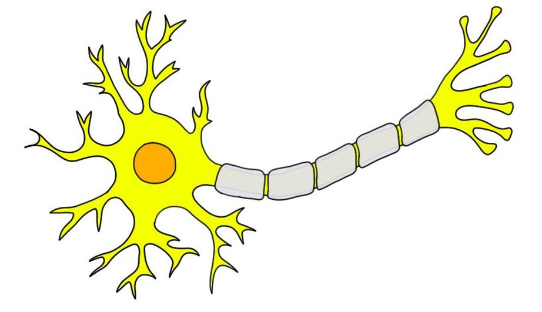

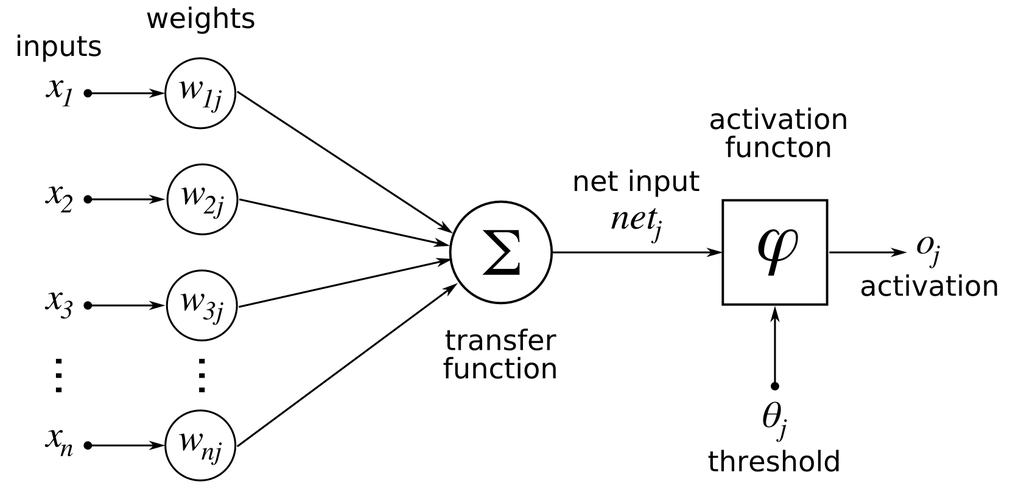

[figure not shown]

# Zastosowania

[figure not shown]

[figure not shown]

Wiele innych, na przykład analiza języka, lub sygnałów dźwiękowych.

http://karpathy.github.io/2015/05/21/rnn-effectiveness/ https://www.youtube.com/watch?v=SacogDL_4JU https://www.youtube.com/watch?v=qv6UVOQ0F44

# Teoria

# Architektury sieci neuronowych

W zależności od zastosowania sieci neuronowe mogą przyjmować różne formy:  
- sieci jednokierunkowe (*feed forward*),  
- sieci rekurencyjne,  
- sieci konwolucyjne.  
- http://www.asimovinstitute.org/neural-network-zoo/

# Sieci jednokierunkowe

- najprosztsze pod względem budowy
- łatwa optymalizacja
- dobre do podstawowych zadań

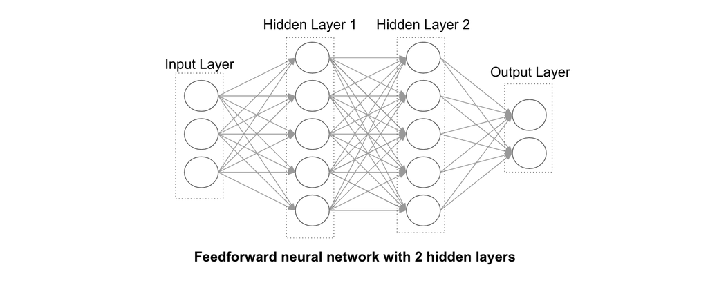

# Reprezentacja macierzowa

- $X$ - macierz danych $N \times D$, gdzie $N$ to ilość obserwacji w danych, a $D$ to ilość kolumn (predyktorów),
- $W$ - macierz wag $D \times O$, gdzie $O$ to ilość neuronów w warstwie
- $b$ - wektor o długości $O$ reprezentujący stałe współczynniki dodawane do każdego z neuronów po obliczeniu wartości w neuronach.

Możemy wtedy zapisać

$$U = XW + b$$

To równanie reprezentuje nam wejściową warstwę sieci neuronowej.

# Reprezentacja macierzowa - funkcja aktywacyjna

Zastanówmy się, czym będzie się różniła kolejna warstwa.

- $U2$ - macierz wag drugiej warstwy $O \times O2$, gdzie $O2$ to ilość neuronów w warstwie
- $b2$ - wektor o długości $O2$ reprezentujący stałe współczynniki,
- $f$ - funkcja aktywacyjna nakładana na wartości poprzedniej warstwy.  
  Wtedy równanie kolejnej warstwy wygląda następująco:

$$U2 = f(U)W2 + b2$$

Takie przedstawienie sieci neuronowej ma swoje zalety:  
- jest proste w zapisie i interpretacji,  
- mnożenie macierzy można przeprowadzić bardzo wydajnie,  
- pozwala na prostą implementację propagacji wstecznej.

# Metoda gradientu prostego

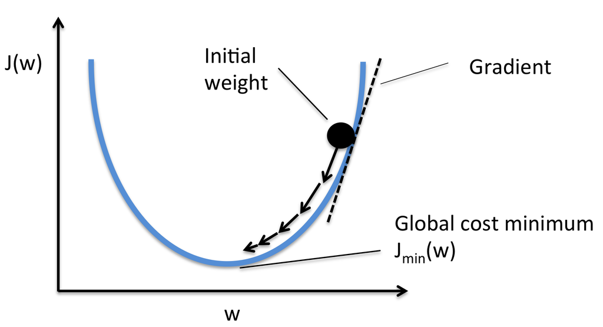

# Propagacja wsteczna

Reguła łańcuchowa:
$$\frac{\partial g}{\partial x} g(f(x)) = \frac{\partial g}{\partial f} \cdot \frac{\partial f}{\partial x}$$

Dołóżmy do naszej sieci ostatnią warstwę, tzn.

$$Y = f(U)W + b$$

Załóżmy też że mamy daną funkcję straty $L(Y)$, oraz znamy jej pochodną $L'$.  
Interesuje nas wpływ (gradient) wag $W$ na funkcję straty $L(Y)$ - pozwoli nam to na dostosowanie wartości wag w celu zmniejszenia funkcji straty.

Chcemy więc policzyć $\frac{\partial L}{\partial W}.$  
Zgodnie z regułą łancuchową mamy więc

$$\frac{\partial L}{\partial W} = \frac{\partial L}{\partial Y} \frac{\partial Y}{\partial W} = \frac{\partial L}{\partial Y} f(U)$$
Jest to tylko przykład, inne przypadki wyjdą w praniu przy praktycznych zadaniach.
Oczywiście zapis gradientu macierzy po macierzy jest sporym uproszczeniem, ale w praktyce wygląda to mniej więcej tak samo - trzeba tylko uważać na wymiary macierzy.

# Praktyka

# Odpalamy notebooki i do dzieła ;)